# HOA #3

Group 18 (Colin, Samam, Cody, Martin)

November 21, 2018

# Assignment

1. Use worksheet “baseball stats” to perform a multiple regression analysis on the dataset found in BB2011 tab, using Wins as the dependent variable, and League, ERA, Runs Scored, Hits Allowed, Walks Allowed, Saves, and Errors as candidates for the independent variables. Perform the analysis at the 5% significance level.
   1. Create a full write up, where you write your statistical analysis step by step. In your write up, make sure you address the following points.
      - Methodology and steps that you took to get to your final regression equation.
      - Final regression equation output.
      - What is the final regression equation?
      - Interpret all the coefficients in the equation.
      - Speak to whether the signs on the coefficients make sense.
      - Interpret R squared.
      - Include a full residual analysis.
      - What is the residual of the Tampa Bay observation?
   2. Now, use tab BB2012 to make predictions of wins in 2012, using the model you created with the 2011 stats.
      - How many games are the Giants (SFG) expected to win in 2012?
      - Which team is predicted by the model to have the worst record in 2012?
      - Which team is predicted by the model to have the best record in 2012?
2. Use the CocaCola data set to analyze quarterly data on Coca Cola’s revenues.
   1. Plot the time series as a line graph. Make sure the graph is polished enough to be included in a formal report - i.e. it has a good title, axis titles/formatting, etc. (extra credit: format the x axis to have years and quarters)
   2. Perform a regression using seasonal binaries. Use 0.1 level of significance for eliminating p-values. Include the final output and write the final regression equation.
   3. Plot the fitted values of your time series on the same graph as the actuals. Does your regression look good?
   4. Interpret the results. Make sure to talk about seasonality.
   5. Use the regression equation to make a prediction for each quarter in 2011.
3. Bob analyzed water damage claims filed at a small Louisiana home insurance company over the last 15 years. He fitted several different trend models, shown below. Which trend model seems most reasonable (or more than one) for making forecasts for the next three years? What about the principle of Occam’s Razor?

# a. Methodology and steps to get final regression equation

### Run step-wise analysis

#### **Model 1** *(Stepwise)*

```
##
## Call:
## lm(formula = wins ~ era + runs_scored + hits_allowed + walks_allowed +
##     saves, data = df1)
##
## Residuals:
##     Min      1Q  Median      3Q     Max
## -8.1138 -2.3786 -0.3709  2.7423  5.6291
##
## Coefficients:
##                Estimate Std. Error t value Pr(>|t|)
## (Intercept)   97.357390  20.364167   4.781 7.25e-05 ***
## era           -9.180495   4.268333  -2.151  0.04177 *
## runs_scored    0.088070   0.009023   9.761 7.87e-10 ***
## hits_allowed  -0.025383   0.018374  -1.381  0.17986
## walks_allowed -0.042792   0.018731  -2.284  0.03148 *
## saves          0.382486   0.132009   2.897  0.00791 **
## ---
## Signif. codes:  0 '***' 0.001 '**' 0.01 '*' 0.05 '.' 0.1 ' ' 1
##
## Residual standard error: 3.715 on 24 degrees of freedom
## Multiple R-squared:  0.9123, Adjusted R-squared:  0.8941
## F-statistic: 49.95 on 5 and 24 DF,  p-value: 6.586e-12
```

### Coefficient interpretation

#### Correlation Matrix

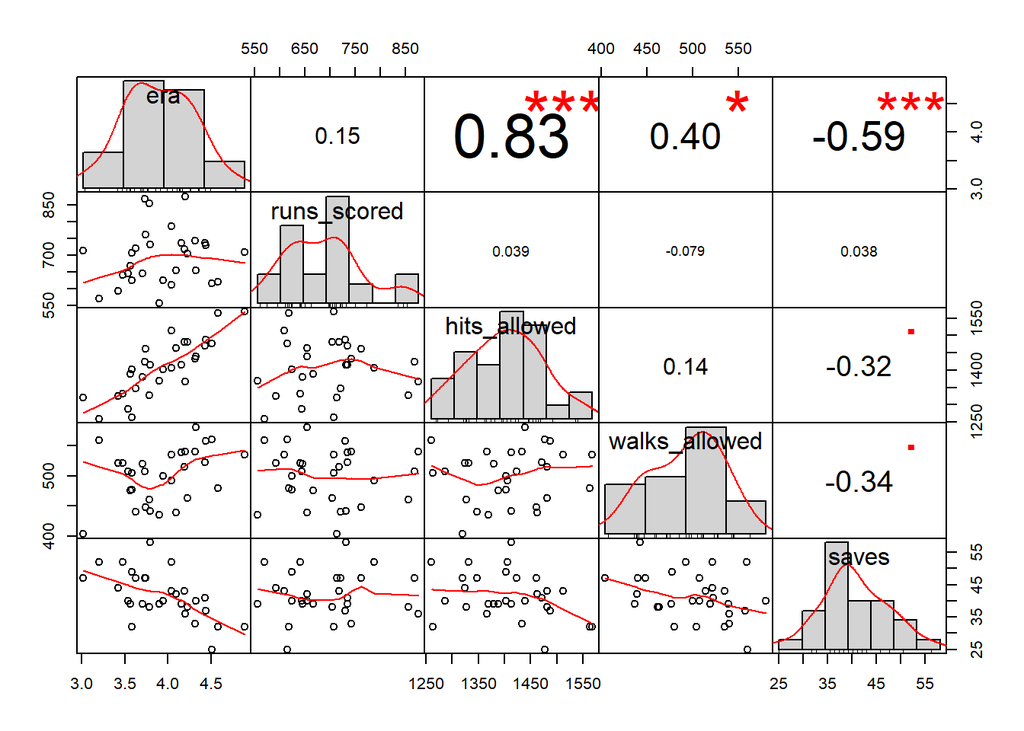

First thing we notice is a high correlation between *Hits Allowed* and *ERA*. Most likely a hit is required to earn a run so that makes sense. *ERA* shows the highest correlation among coefficients. *Runs Scored* has the lowest correlation with other coefficients. This makes a lot of sense because *Runs Scored* is an offensive parameter, whereas all other coefficients are defensive parameters.

#### R squared and Adj. R squared

R squared = 0.9123323 & Adj R sqaured = 0.8940682

R sqaured high indicating a good fit, and also the gap between R sqaured and Adj R squared is small which indicates a more parsimonious model.

### Residual Analysis

No clear pattern so no reason to suspect heteroscedasticity

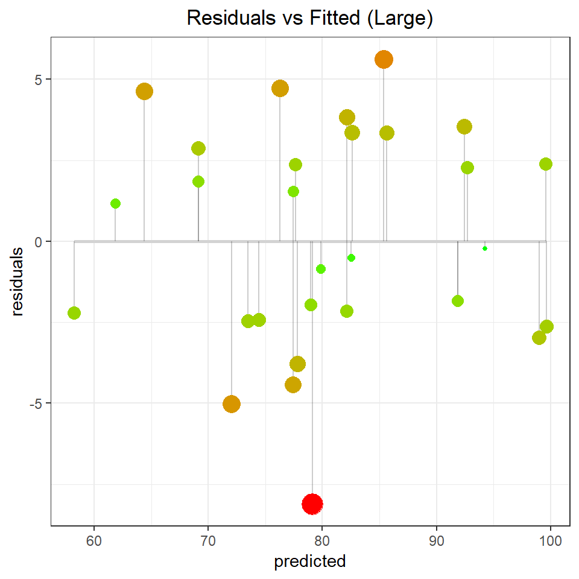

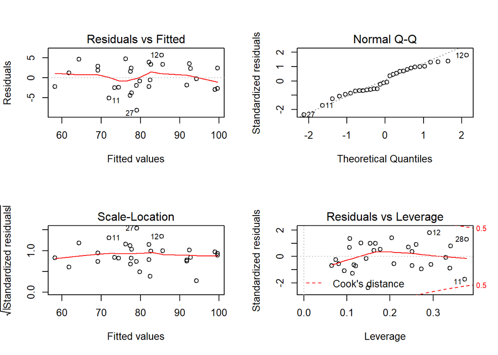

Normal QQ plot looks good the more extreme standardized residuals (eg >|1| ) tent to slant above and below the identity line. This indicated a slight left skew with a light tail. Scale location of residuals doesn’t give us much more information from fitted v residuals because we don’t have any outliers. No influential cases arise from “Residuals vs Leverage” as all of the cases are within the the dashed Cook’s distance line, although point 28 and 11 are close.

## Evans’ Rule

#### **Model 2** *(ERA + Runs Scored to predict wins)*

```
##
## Call:
## lm(formula = wins ~ era + runs_scored, data = df1)
##
## Residuals:
##     Min      1Q  Median      3Q     Max
## -9.9036 -2.5239 -0.1011  3.0028  6.8683
##
## Coefficients:
##               Estimate Std. Error t value Pr(>|t|)
## (Intercept)  87.602486   9.429710   9.290 6.73e-10 ***
## era         -18.882502   1.894967  -9.965 1.53e-10 ***
## runs_scored   0.097604   0.009951   9.808 2.15e-10 ***
## ---
## Signif. codes:  0 '***' 0.001 '**' 0.01 '*' 0.05 '.' 0.1 ' ' 1
##
## Residual standard error: 4.373 on 27 degrees of freedom
## Multiple R-squared:  0.8634, Adjusted R-squared:  0.8533
## F-statistic: 85.32 on 2 and 27 DF,  p-value: 2.135e-12
```

### Coefficient interpretation

Both predictors, ERA and Runs Scored are significant at .001 level. Every one point drop in ERA adds 19 to Wins. Every 10 Runs Scored adds 1 to Wins.

#### Correlation Matrix

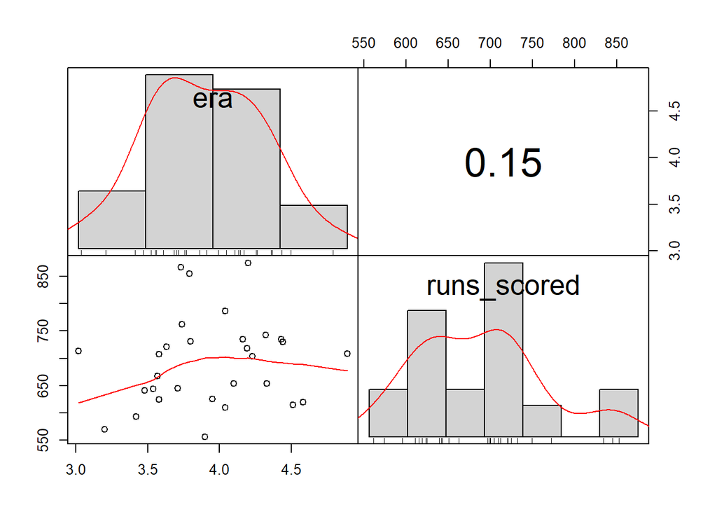

Looks great. Low correlation, but as expected, positive correlation.

### Residual Analysis

No clear pattern so no reason to suspect heteroscedasticity

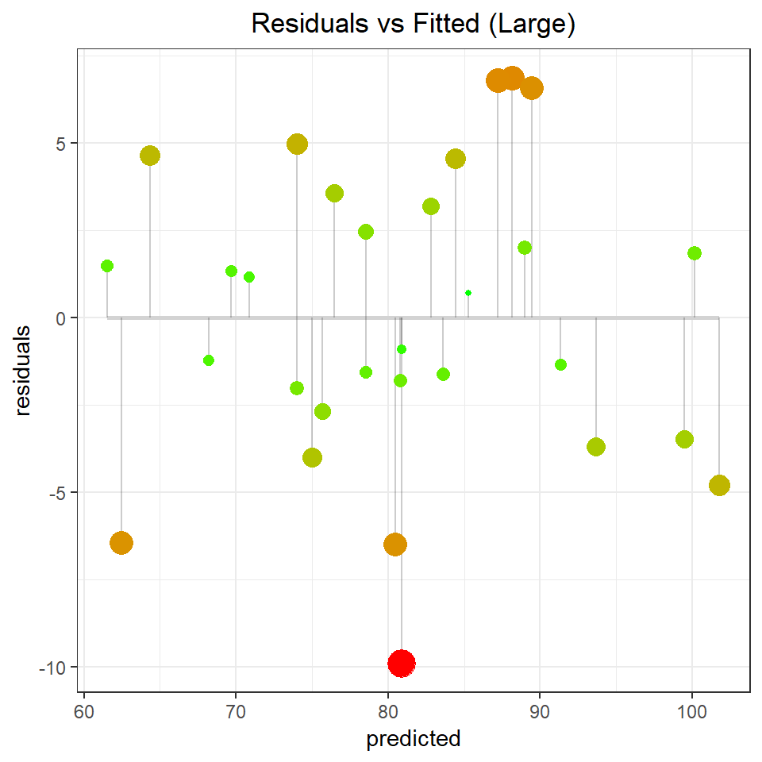

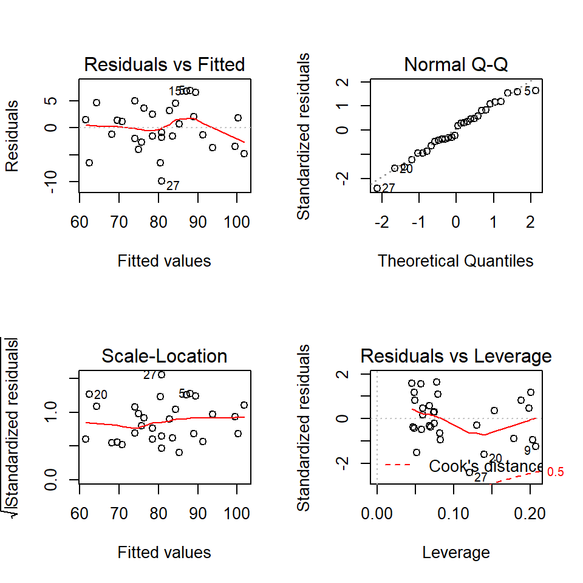

Normal QQ plot looks good, slight left skew with a light tail. No influential cases based on our residuals plots.

## Model Decision

Model 2 is ultimately a better choice even though R squared is lower. The model uses less predictors so there is less chance of overfitting. With only 30 observations, less predictors the better.

#### Residual of Tampa Bay

```
## # A tibble: 1 x 2
##   team      residuals
##   <fct>         <dbl>
## 1 Tampa Bay      4.94
```

# b. 2012 Predictions *(Model 1 vs Model 2 v Actual)*

*SFG 2012 wins*

**Model 1:** San Francisco, 92 v **Model 2:** San Francisco, 88 v **Actual:** San Francisco, 94

*Worst record of 2012 and team*

**Model 1:** Houston, 58 v **Model 2:** Houston, 58 v **Actual:** Houston, 55

*Best Record of 2012 and team*

**Model 1:** New York Yankees, 98 v **Model 2:** Washington, 96 v **Acual:** Washington, 94 ***